# Assignment 1

# Introduction

This assignment makes use of data from a personal activity monitoring device. This device collects data at 5 minute intervals through out the day. The data consists of two months of data from an anonymous individual collected during the months of October and November, 2012 and include the number of steps taken in 5 minute intervals each day.

# Data

The data for this assignment can be downloaded from the course web site:  
- Dataset: [Activity monitoring data](https://d396qusza40orc.cloudfront.net/repdata%2Fdata%2Factivity.zip)

The variables included in this dataset are:  
- steps: Number of steps taking in a 5-minute interval (missing values are coded as NA)  
- date: The date on which the measurement was taken in YYYY-MM-DD format  
- interval: Identifier for the 5-minute interval in which measurement was taken

The dataset is stored in a comma-separated-value (CSV) file and there are a total of 17,568 observations in this dataset.

Download and unzip the Dataset to the working directory.

## Loading the Dataset

```r
adata <- read.csv('activity.csv')
```

## What is mean total number of steps taken per day?

#### 1, Total number of steps taken per day

```r
sum_dailysteps <- aggregate(steps ~ date, data=adata, FUN="sum", na.rm=TRUE)
```

#### 2, Histogram of the total number of steps taken each day

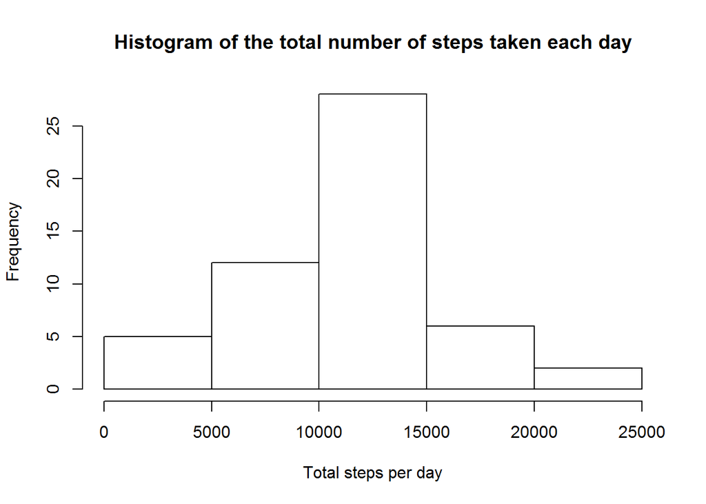

```r
hist(sum_dailysteps$steps, main="Histogram of the total number of steps taken each day", xlab="Total steps per day")
```

#### 3, Mean and median of the total number of steps taken per day

```r
mean(sum_dailysteps$steps)
```

```
## [1] 10766.19
```

```r
median(sum_dailysteps$steps)
```

```
## [1] 10765
```

## What is the average daily activity pattern?

#### 1, Time series plot of the 5-minute interval and the average number of steps taken, averaged across all days

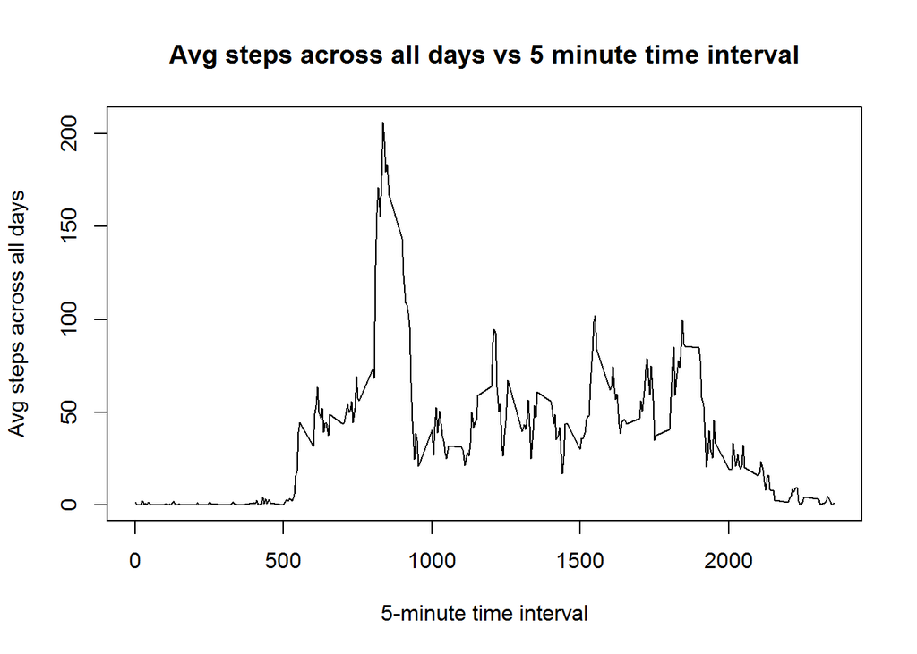

```r
avg_5minsteps <- aggregate(steps ~ interval, data=adata, FUN="mean", na.rm=TRUE)
plot(avg_5minsteps$interval,avg_5minsteps$steps,type = "l",main="Avg steps across all days vs 5 minute time interval",xlab="5-minute time interval",ylab="Avg steps across all days")
```

#### 2, Which 5-minute interval, on average across all the days in the dataset, contains the maximum number of steps?

```r
avg_5minsteps$interval[which.max(avg_5minsteps$steps)]
```

```
## [1] 835
```

## Imputing missing values

There are a number of days/intervals where there are missing values (coded as NA). The presence of missing days may introduce bias into some calculations or summaries of the data.

#### 1, The total number of missing values in the dataset

```r
sum(is.na(adata$steps))
```

```
## [1] 2304
```

#### 2, Devise a strategy for filling in all of the missing values in the dataset.

I choose to use 5-minute interval average steps to replace all NA in the original dataset.

```r
adata_merge <- merge(adata,avg_5minsteps,by="interval")
adata_merge$steps.x[is.na(adata_merge$steps.x)]<-adata_merge$steps.y
```

#### 3, Create a new dataset that is equal to the original dataset but with the missing data filled in.

```r
keep <- c("interval","steps.x","date")
new_adata<-adata_merge[keep]
colnames(new_adata) <- c("interval","steps","date")
library(plyr)
new_adata<-arrange(new_adata,date,interval)
```

#### 4, Make a histogram of the total number of steps taken each day and calculate and report the mean and median total number of steps taken per day. Do these values differ from the estimates from the first part of the assignment? What is the impact of imputing missing data on the estimates of the total daily number of steps?

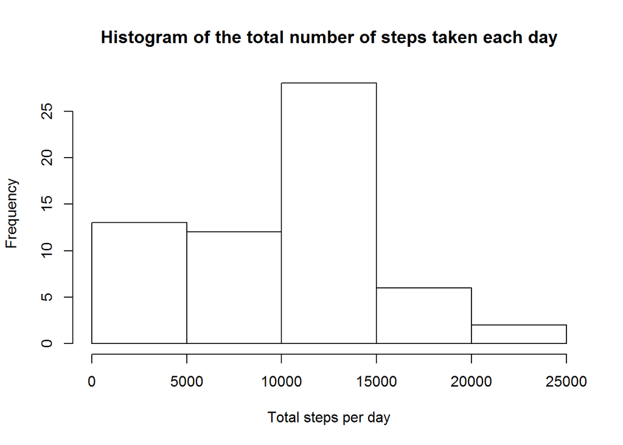

```r
new_sum_dailysteps <- aggregate(steps ~ date, data=new_adata, FUN="sum", na.rm=TRUE)
hist(new_sum_dailysteps$steps,main="Histogram of the total number of steps taken each day", xlab="Total steps per day")
```

```r
mean(new_sum_dailysteps$steps)
```

```
## [1] 9371.437
```

```r
median(new_sum_dailysteps$steps)
```

```
## [1] 10395
```

By replacing NA with the 5-minute interval average steps, the mean and median become smaller compared to the first part of the assignment. This means that most of NA in the original dataset are those time interval that have smaller 5-minute interval average steps.

## Are there differences in activity patterns between weekdays and weekends?

#### 1, Create a new factor variable in the dataset with two levels - “weekday” and “weekend” indicating whether a given date is a weekday or weekend day.

```r
wde<-lapply(as.Date(new_adata$date), function(x) if (weekdays(x)<"Saturday") {return("weekday")} else {return("weekend")})
new_adata$day_type<-unlist(wde)
```

#### 2,Make a panel plot containing a time series plot (i.e. type = “l”) of the 5-minute interval (x-axis) and the average number of steps taken, averaged across all weekday days or weekend days (y-axis).

```r
new_avg_5minsteps <- aggregate(steps ~ interval+day_type, data=new_adata, FUN="mean", na.rm=TRUE)
library(lattice)
```

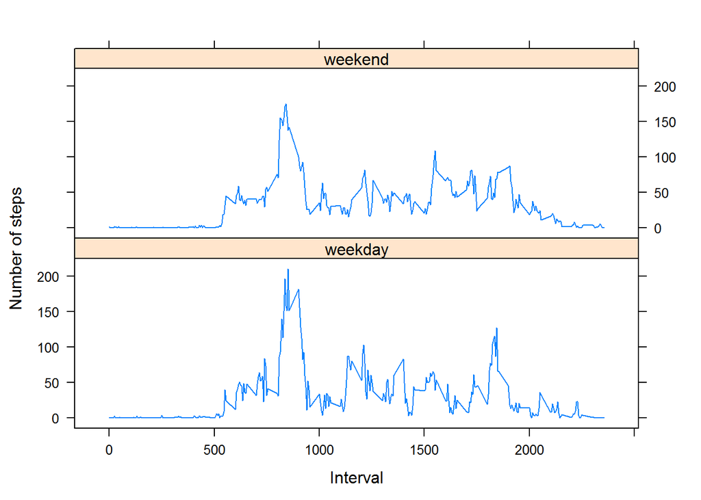

```r
xyplot(steps ~ interval | day_type, data=new_avg_5minsteps, type = "l", layout = c(1, 2), xlab="Interval",ylab="Number of steps")
```